# Portal Rodent Abundance Demo

Hao Ye

2026-01-28

# Introduction

This vignette is a basic guide to begin exploring the Portal data. We load in the data (making sure that we’re using the most recent copy from GitHub), and then explore the rodent abundances over time, with a comparison between the “control” and “kangaroo rat exclosure” treatments.

## Package Setup

First we load several packages:

- `tidyverse` contains several packages for data manipulation and plotting.
- `cowplot` contains a nicer default theme for ggplot.
- `portalr` is this package, which contains functions to read in the Portal data and do some basic processing.

```r
library(dplyr)
library(tidyr)
library(ggplot2)
library(cowplot)
library(portalr)
```

# Retrieving the Data

Note that this package does not contain the actual Portal data, which resides online in a [GitHub repository](https://github.com/weecology/PortalData).

First, we try to load the data. If there isn’t a Portal folder, than `load_rodent_data` will fall back to downloading the data, as well.

```r
portal_data_path <- tempdir() # use a temporary folder to store downloaded data
data_tables <- load_rodent_data(portal_data_path, download_if_missing = TRUE)
```

The `load_rodent_data` function reads in several tables related to the rodent abundances. We won’t necessarily use all of these tables, but loading this now gives us access later.

```r
print(summary(data_tables))
```

```
#>                Length Class      Mode
#> rodent_data    31     data.frame list
#> species_table  15     data.frame list
#> trapping_table  8     data.frame list
#> newmoons_table  4     data.frame list
#> plots_table     6     data.frame list
```

# Rodent Abundances

The first table that we loaded (`data_tables$rodent_data`) is a record of whatever was found in the traps, mostly rodents, but also a few other taxa. If we just wanted to get the rodent abundance data, we could use the `abundance` function, which has default arguments to filter out the non-rodents.

```r
# get rodent abundance by plot
rodent_abundance_by_plot <- abundance(path = portal_data_path, time = "date", level = "plot")
```

```
#> Loading in data version 6.48.0
```

```r
rodent_abundance <- rodent_abundance_by_plot %>%
  gather(species, abundance, -censusdate, -treatment, -plot) %>%
  count(species, censusdate, wt = abundance) %>%
  rename(abundance = n)
print(summary(rodent_abundance))
```

```
#>    species            censusdate           abundance
#>  Length:9765        Min.   :1979-09-22   Min.   :  0.000
#>  Class :character   1st Qu.:1990-02-24   1st Qu.:  0.000
#>  Mode  :character   Median :2000-02-05   Median :  0.000
#>                     Mean   :2001-01-01   Mean   :  6.884
#>                     3rd Qu.:2011-08-27   3rd Qu.:  5.000
#>                     Max.   :2024-12-07   Max.   :334.000
```

Let’s convert the data to long format for easier facetting. Also, we want the scientific names instead of the two-letter species codes, so let’s do that matching, too:

```r
join_scientific_name <- function(rodent_abundance,
                                 species_table = data_tables$species_table)
{
  return(rodent_abundance %>%
           left_join(select(species_table, "species", "scientificname"),
                     by = "species") %>%
           rename(scientific_name = scientificname)
  )
}

rodent_abundance <- join_scientific_name(rodent_abundance)
```

## Figure: abundance over time

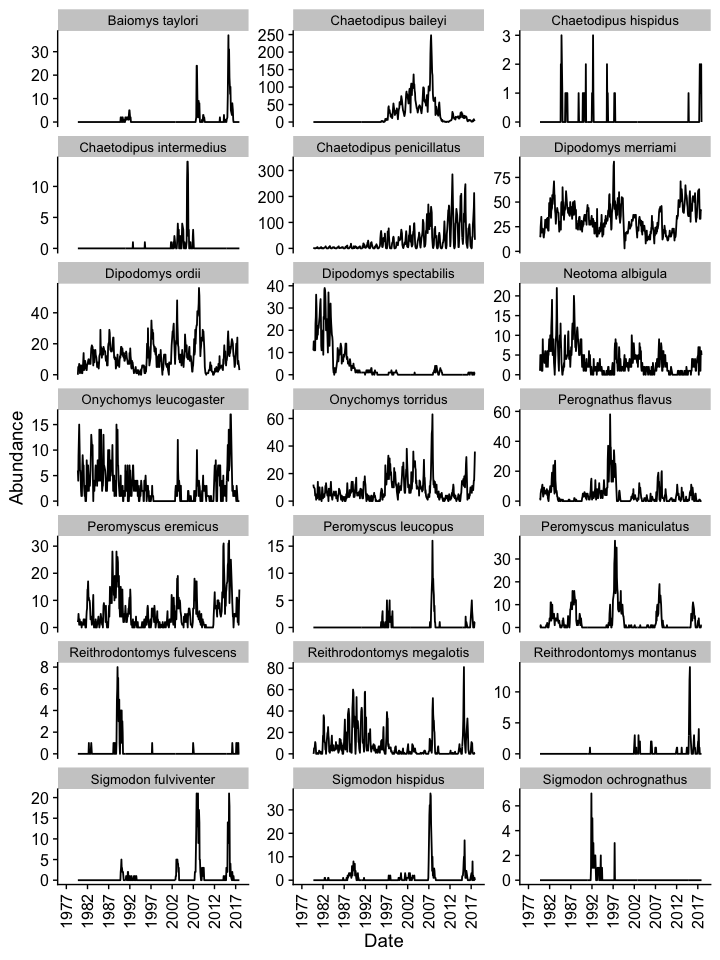

Monthly abundance of rodents (all plots)

```r
make_abundance_plot_over_time <- function(rodent_abundance)
{
  return(ggplot(rodent_abundance,
                aes(x = censusdate, y = abundance)) +
           geom_line() +
           facet_wrap(~scientific_name, scales = "free_y", ncol = 3) +
           xlab("Date") +
           ylab("Abundance") +
           scale_x_date(breaks = seq(as.Date("1977-01-01"), to = as.Date("2018-01-01"), "+5 years"),
                        date_labels = "%Y",
                        limits = as.Date(c("1977-01-01", "2018-01-01"))) +
           theme_cowplot() +
           theme(axis.text.x = element_text(angle = 90, hjust = 1, vjust = 0.5),
                 legend.position = "bottom", legend.justification = "center",
                 strip.text.x = element_text(size = 10))
  )
}

my_plot <- make_abundance_plot_over_time(rodent_abundance)

print(my_plot)
```

## Next Steps

Our next steps would likely be to dig deeper into the rodent abundances for different treatments, but first we want to know what the different treatments look like, so let’s revisit the abundances later.

# Plot Treatments

A description of the experimental design and treatments can be found in this [Readme file](https://github.com/weecology/PortalData/tree/main/SiteandMethods) in the PortalDate repo.

For now, we are just going to use the [`Portal_plots`](https://github.com/weecology/PortalData/blob/main/SiteandMethods/Portal_plots.csv) table file to look at how the treatments for individual plots have changed over time. Note that this file is already loaded in as the `plots_table` from the `loadData` function we ran previously.

```r
print(summary(data_tables$plots_table))
```

```
#>       year          month             plot        treatment
#>  Min.   :1977   Min.   : 1.000   Min.   : 1.00   Length:11948
#>  1st Qu.:1989   1st Qu.: 4.000   1st Qu.: 6.00   Class :character
#>  Median :2000   Median : 7.000   Median :12.00   Mode  :character
#>  Mean   :2000   Mean   : 6.556   Mean   :12.48
#>  3rd Qu.:2012   3rd Qu.:10.000   3rd Qu.:18.00
#>  Max.   :2024   Max.   :12.000   Max.   :24.00
#>  resourcetreatment  anttreatment
#>  Length:11948       Length:11948
#>  Class :character   Class :character
#>  Mode  :character   Mode  :character
#>
#>
#>
```

We want a proper date variable as well as converting `plot` into a factor:

```r
plot_treatments <- data_tables$plots_table %>%
  mutate(iso_date = as.Date(paste0(year, "-", month, "-", "01")),
         plot = as.factor(plot)) %>%
  select(iso_date, plot, treatment)
```

## Figure: plot treatments over time

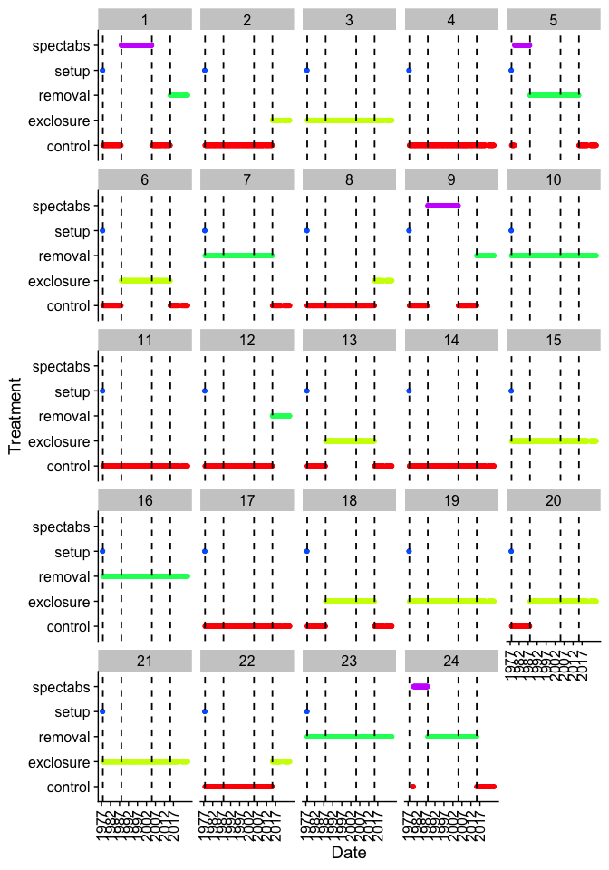

Treatments of Plots by Date

```r
my_plot <- ggplot(plot_treatments,
                  aes(x = iso_date, y = treatment, color = treatment)) +
  geom_point(shape = 20) +
  geom_vline(aes(xintercept = as.Date("1977-10-01")), linetype = 2) +
  geom_vline(aes(xintercept = as.Date("1988-01-01")), linetype = 2) +
  geom_vline(aes(xintercept = as.Date("2005-01-01")), linetype = 2) +
  geom_vline(aes(xintercept = as.Date("2015-04-01")), linetype = 2) +
  facet_wrap(~plot, ncol = 5) +
  xlab("Date") +
  ylab("Treatment") +
  scale_color_manual(values = rainbow(5)) +
  scale_x_date(breaks = seq(as.Date("1977-01-01"), to = as.Date("2018-01-01"), "+5 years"), date_labels = "%Y") +
  theme_cowplot() +
  guides(color = "none") +
  theme(axis.text.x = element_text(angle = 90, hjust = 1, vjust = 0.5))

print(my_plot)
```

## Identifying control plots

The treatments for the plots have changed over time: in some cases, this was due to initial ramping up of the experimental protocol, in others, exclusions of *Dipodomys spectabilis* were started and then converted back later because the species went locally extinct (e.g. plots 1, 5, 9, 24).

### Which plots have always been control plots?

```r
always_control_plots <- summarise_rodent_data(level = "plot",plots = "Longterm") %>%
  group_by(plot) %>%
  summarize(always_control = all(treatment == "control")) %>%
  filter(always_control)
```

[output not shown]

```r
print(always_control_plots)
```

```
#> # A tibble: 4 × 2
#>    plot always_control
#>   <int> <lgl>
#> 1     4 TRUE
#> 2    11 TRUE
#> 3    14 TRUE
#> 4    17 TRUE
```

The `plots = "Longterm"` argument only returns plots that have never changed treatment type. Note, however, that this excludes several plots for which the treatment was changed ~2015. We can include these plots by filtering by date and testing for the “control” treatment manually:

```r
mostly_control_plots <- plot_treatments %>%
  filter(iso_date < "2015-01-01",
         iso_date > "1998-01-01") %>%
  group_by(plot) %>%
  summarize(mostly_control = all(treatment == "control")) %>%
  filter(mostly_control)

print(mostly_control_plots)
```

```
#> # A tibble: 8 × 2
#>   plot  mostly_control
#>   <fct> <lgl>
#> 1 2     TRUE
#> 2 4     TRUE
#> 3 8     TRUE
#> 4 11    TRUE
#> 5 12    TRUE
#> 6 14    TRUE
#> 7 17    TRUE
#> 8 22    TRUE
```

And to identify the datespan over which these plots have been controls:

```r
date_span <- plot_treatments %>%
  filter(plot %in% mostly_control_plots$plot) %>%
  group_by(iso_date) %>%
  summarize(all_control = all(treatment == "control")) %>%
  filter(all_control)

print(date_span)
```

```
#> # A tibble: 408 × 2
#>    iso_date   all_control
#>    <date>     <lgl>
#>  1 1977-10-01 TRUE
#>  2 1977-11-01 TRUE
#>  3 1977-12-01 TRUE
#>  4 1978-01-01 TRUE
#>  5 1978-02-01 TRUE
#>  6 1978-03-01 TRUE
#>  7 1978-04-01 TRUE
#>  8 1978-05-01 TRUE
#>  9 1978-06-01 TRUE
#> 10 1978-07-01 TRUE
#> # ℹ 398 more rows
```

## Abundances over control plots

We are now ready to plot abundances just over the control plots and the time span in 1977-10-01 to 2015-03-01. We do this by retrieving the abundance data by plot, and then filtering accordingly:

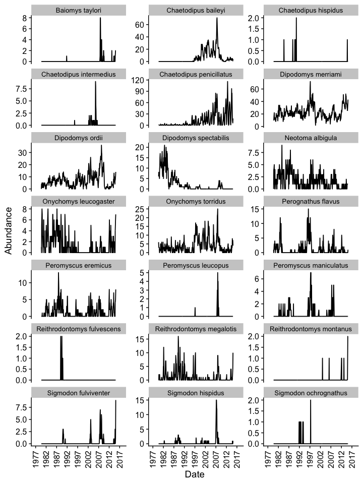

Monthly abundance of rodents (control plots)

```r
rodent_abundance_by_plot %>%
  filter(censusdate >= min(date_span$iso_date),
         censusdate <= max(date_span$iso_date),
         plot %in% mostly_control_plots$plot) %>%
  select(-treatment, -plot) %>%
  gather(species, abundance, -censusdate) %>%
  count(censusdate, species, wt = abundance) %>%
  rename(abundance = n) %>%
  join_scientific_name() %>%
  {.} -> rodent_abundance_control

rodent_abundance_control %>%
  make_abundance_plot_over_time() %>%
  print()
```

## Abundances over rodent exclosures

We can do the same with the “exclosure” condition. First, which plots:

```r
mostly_exclosure_plots <- plot_treatments %>%
  filter(iso_date > as.Date("1989-01-01"),
         iso_date < "2015-01-01") %>%
  group_by(plot) %>%
  summarize(mostly_exclosure = all(treatment == "exclosure")) %>%
  filter(mostly_exclosure)

print(mostly_exclosure_plots)
```

```
#> # A tibble: 8 × 2
#>   plot  mostly_exclosure
#>   <fct> <lgl>
#> 1 3     TRUE
#> 2 6     TRUE
#> 3 13    TRUE
#> 4 15    TRUE
#> 5 18    TRUE
#> 6 19    TRUE
#> 7 20    TRUE
#> 8 21    TRUE
```

Then, the datespan:

```r
date_span <- plot_treatments %>%
  filter(plot %in% mostly_exclosure_plots$plot) %>%
  group_by(iso_date) %>%
  summarize(all_exclosure = all(treatment == "exclosure")) %>%
  filter(all_exclosure)

print(date_span)
```

```
#> # A tibble: 297 × 2
#>    iso_date   all_exclosure
#>    <date>     <lgl>
#>  1 1988-01-01 TRUE
#>  2 1988-02-01 TRUE
#>  3 1988-03-01 TRUE
#>  4 1988-04-01 TRUE
#>  5 1988-05-01 TRUE
#>  6 1988-06-01 TRUE
#>  7 1988-07-01 TRUE
#>  8 1988-08-01 TRUE
#>  9 1988-09-01 TRUE
#> 10 1988-10-01 TRUE
#> # ℹ 287 more rows
```

Finally, the figure:

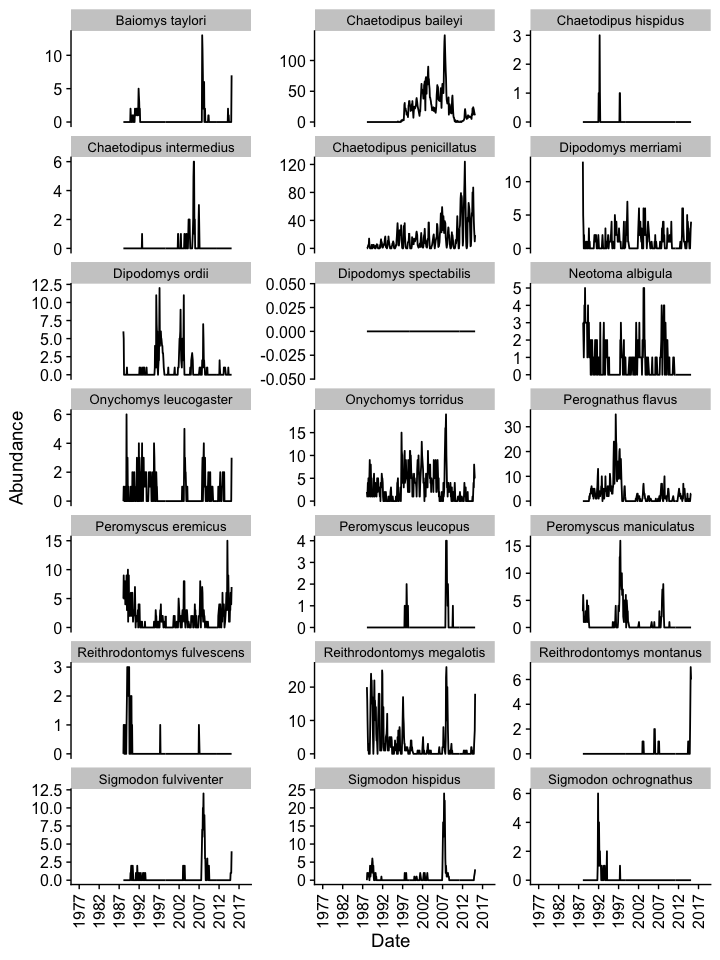

Monthly abundance of rodents (exclosure plots)

```r
rodent_abundance_by_plot %>%
  filter(censusdate >= min(date_span$iso_date),
         censusdate <= max(date_span$iso_date),
         plot %in% mostly_exclosure_plots$plot) %>%
  select(-treatment, -plot) %>%
  gather(species, abundance, -censusdate) %>%
  count(censusdate, species, wt = abundance) %>%
  rename(abundance = n) %>%
  join_scientific_name() %>%
  {.} -> rodent_abundance_exclosure

rodent_abundance_exclosure %>%
  make_abundance_plot_over_time() %>%
  print()
```

Since these data have the same number of plots as the previous figure, we can directly compare abundances. Note the decreased numbers for kangaroo rats (*Dipodomys spp.*) and increased numbers for some other taxa.

## Comparison Figure

Let’s merge the two datasets and produce a combined plot:

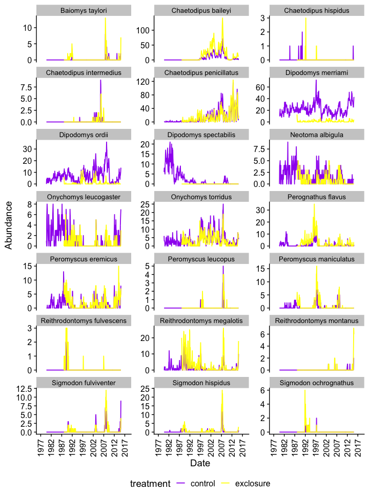

Monthly abundance of rodents (control vs. exclosure plots)

```r
rodent_abundance_merged <- bind_rows(
  mutate(rodent_abundance_control, treatment = "control"),
  mutate(rodent_abundance_exclosure, treatment = "exclosure"))

merged_plot <- ggplot(rodent_abundance_merged,
                      aes(x = censusdate, y = abundance, color = treatment)) +
  geom_line() +
  facet_wrap(~scientific_name, scales = "free_y", ncol = 3) +
  xlab("Date") +
  ylab("Abundance") +
  scale_x_date(breaks = seq(as.Date("1977-01-01"), to = as.Date("2018-01-01"), "+5 years"),
               date_labels = "%Y",
               limits = as.Date(c("1977-01-01", "2018-01-01"))) +
  scale_color_manual(values = c("purple", "yellow")) +
  theme_cowplot() +
  theme(axis.text.x = element_text(angle = 90, hjust = 1, vjust = 0.5),
        legend.position = "bottom", legend.justification = "center",
        strip.text.x = element_text(size = 10))

print(merged_plot)
```

As expected, there are substantially lower counts of kangaroo rats (*Dipodomys spp.*) in the “exclosure” plots. We also observe very similar abundances for some species, but increases in others (e.g. “Chaetodipus baileyi”, “Perognathus flavus”, “Reithrodontomys megalotis”)